# Exercises: Networks

Berry Brosi

August 2024

# Packages

Make sure to load these packages!

```r
# ONLY IF NEEDED---uncomment if so:
# install.packages("tidyverse")
# install.packages("kableExtra")
# install.packages("bipartite")

library(tidyverse)
library(kableExtra)
library(bipartite)
```

# Exercise 2: edge List to bipartite

This should be very straightforward, as the code was included in the exercise text (repeated below):

```r
weighted <- read.csv(file.choose()) # pop-up window to select `medgarden.csv`

bipart.med <- weighted %>%
  group_by(plant, pollinator) %>%
  tally() %>%
  pivot_wider(id_cols = c("plant"), # plants are the rows
              names_from = pollinator, # names of new columns: unique pollinators
              values_from = n, # values in the matrix from tallied interactions
              values_fill = 0) # if no value, enter zero (otherwise NA)
```

You should have gotten this bipartite network back (again, included in the exercise file):

| plant | Osmia | Bombus | Syrphid | Halictid | Muscid | Ant | Hummingbird |
| --- | --- | --- | --- | --- | --- | --- | --- |
| Borago officinalis | 1 | 0 | 0 | 0 | 0 | 0 | 0 |
| Camassia leichtlinii | 0 | 1 | 2 | 0 | 0 | 0 | 0 |
| Catharanthus roseus | 0 | 0 | 1 | 0 | 0 | 0 | 0 |
| Coclearia afficinalis | 0 | 0 | 1 | 1 | 1 | 0 | 0 |
| Eriogonum umbellatum | 0 | 0 | 2 | 0 | 0 | 0 | 0 |
| Erysimum asperum | 0 | 0 | 4 | 1 | 0 | 2 | 0 |
| Gilia capitata | 1 | 0 | 1 | 0 | 0 | 0 | 0 |
| Glaucium flavum | 0 | 1 | 0 | 0 | 0 | 0 | 0 |
| Helleborus orientalis | 0 | 0 | 0 | 0 | 1 | 0 | 0 |
| Heuchera micrantha | 0 | 0 | 0 | 1 | 1 | 0 | 0 |
| Heuchera sanguinea | 1 | 0 | 0 | 0 | 0 | 0 | 0 |
| Horminum pyrenaicum | 0 | 0 | 3 | 0 | 0 | 0 | 0 |
| Hydrophyllum virginiana | 0 | 0 | 4 | 0 | 1 | 0 | 0 |
| Iris douglasiana | 0 | 0 | 0 | 0 | 1 | 0 | 0 |
| Polemonium reptans | 3 | 0 | 0 | 0 | 2 | 0 | 0 |
| Polygonum bisorta | 0 | 0 | 0 | 3 | 1 | 0 | 0 |
| Rhodiola rosea | 0 | 0 | 0 | 0 | 1 | 0 | 0 |
| Ruta graveolens | 0 | 0 | 0 | 2 | 0 | 0 | 0 |
| Sedua spathulifolium | 1 | 0 | 1 | 0 | 0 | 0 | 0 |
| Smilacina stellata | 0 | 0 | 0 | 0 | 1 | 0 | 0 |
| Thymus leucospermus | 1 | 0 | 1 | 2 | 0 | 0 | 0 |
| Tragopogon porrifolius | 0 | 0 | 0 | 0 | 0 | 0 | 1 |
| Wyethia angustifolia | 1 | 6 | 2 | 0 | 0 | 0 | 0 |

### Optional bonus 2.1 *(Rmarkdown only)*

again, the code was included with the exercise and is repeated below; you should get back the table above

```r
# show in nicely-formatted table:
kable(bipart.med, row.names = F, ) %>% kable_styling(full_width = F,
  position = "left", bootstrap_options = "condensed")
```

### Optional bonus 2.2

Import an edge list of your own data and convert it to a bipartite matrix. **(No key for this!)**

# Exercise 3: plotting with visweb

Using the “medgarden” data you put into matrix form (now called `bipart.med`):

- plot via `visweb`:
  - with `type = "none"`
  - with `type = "nested"`
  - with `type = "diagonal"`

First, change formatting of `bipart.med` as included in the exercise:

```r
# save plant names
plant = bipart.med$plant
# remove plant column
bipart.med = bipart.med[,-1]
# convert to matrix
bipart.med = as.matrix(bipart.med)
# add plants to row names
row.names(bipart.med) = plant
# remove `plant` variable (just to keep workspace clean)
rm(plant)
```

Then plot via `visweb()`: code and plots are below:

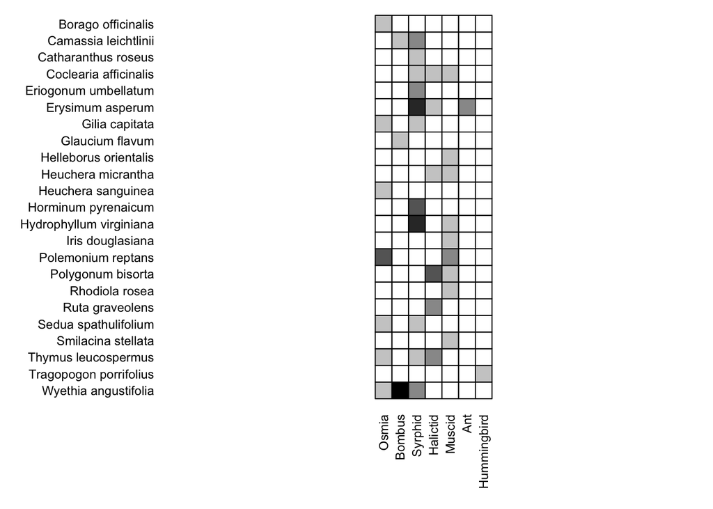

```r
# none
visweb(bipart.med, type = "none")
```

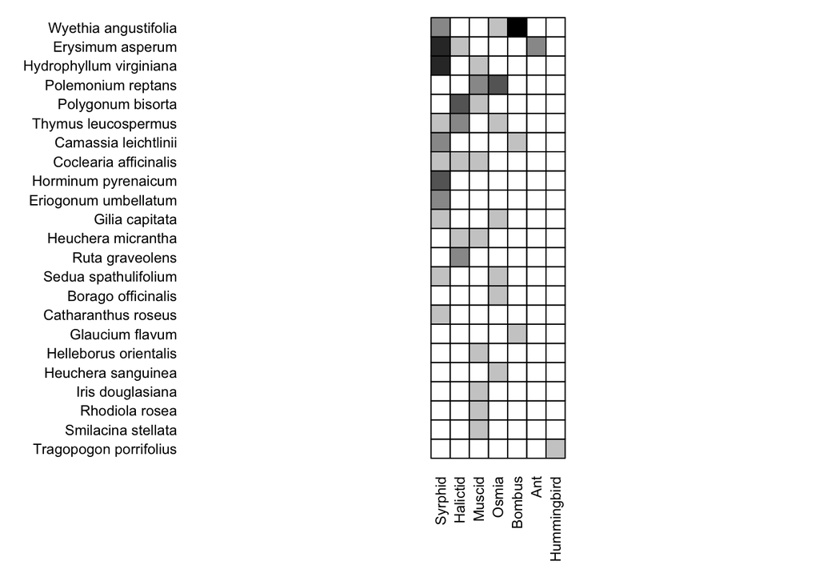

```r
# nested
visweb(bipart.med, type = "nested")
```

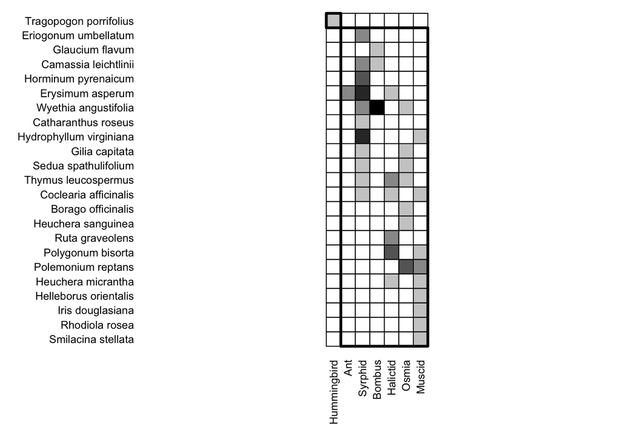

```r
# diagonal
visweb(bipart.med, type = "diagonal")
```

*note:* the `visweb` defaults often have labels that are spaced quite far away from the matrix itself… there are workarounds to that, but they’re kind of a pain and not worth getting into here.

**After you have plotted with `type = "diagonal"`:** the `diagonal` method is set up to show modularity in the network. How many modules do you see in the “med garden” network? Can you comment on the modules qualitatively in terms of the organisms involved?

- there are **two** modules outlined in boxes
  - (the example we showed in the slides during the meeting did not display those, as the Motten 1982 network has no noticeable modularity)
- one of the modules is hummingbirds on one plant (*Tragopogon*); the other module is everything else!
  - alternatively, we could say that insects and the plants they interact with are one module, and non-insects are the other module

### Optional bonus 3.1

Also straightforward, directly following the code below (included in exercise) to order the rows and columns of the `bipart.med` matrix:

```r
rows = rowSums(bipart.med>0) # calculate row sums
cols = colSums(bipart.med>0) # calculate column sums
roworder = order(rows, decreasing = T) # order rows by sum
colorder = order(cols, decreasing = T) # order columns by sum
bipart.med = bipart.med[roworder,colorder] # re-order rows and cols in matrix
```

Re-plot with `type = "none"`; plot below

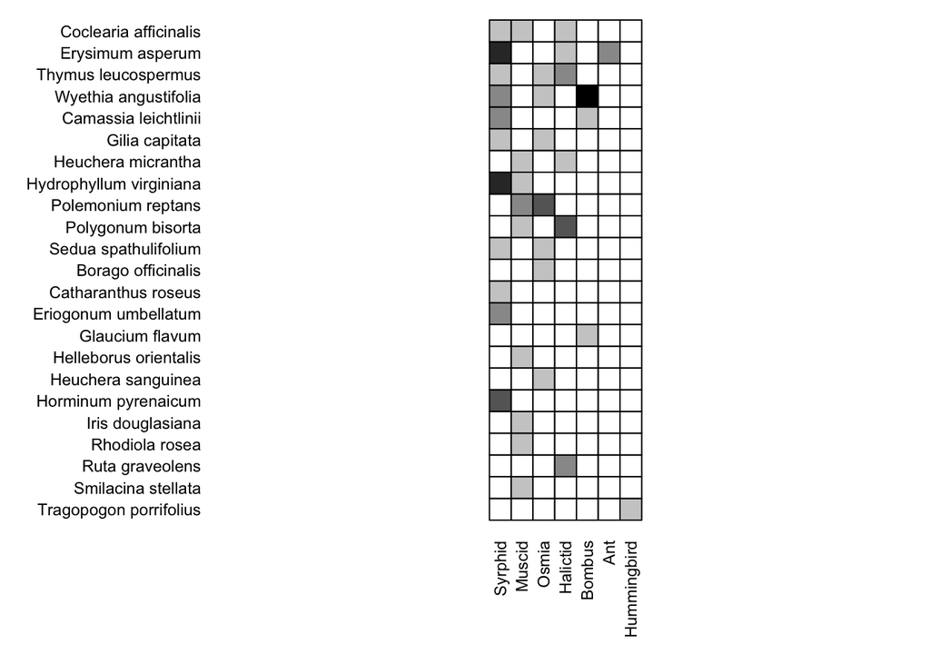

```r
visweb(bipart.med, type = "none")
```

### Optional bonus 3.2

*Play around with visualizing some of the other datasets included in bipartite, for example the `Safariland` or `Memmott1999` datasets. To access those datasets, use `data(Safariland)` or `data(memmott1999)`*

**(No key for this!)**

# Exercise 8: network metrics

Use the `bipart.med` data you have been using so far to calculate:

- $H_2'$ (network-level specialization); in `networklevel`, use `index = "H2"`
- connectance

code and answers:

```r
networklevel(bipart.med, index = "H2")
```

```
##        H2
## 0.5053819
```

```r
networklevel(bipart.med, index = "connectance")
```

```
## connectance
##   0.2360248
```

### Optional bonus 8.1

calculate multiple metrics for the `bipart.med` data and/or other datasets included in the `bipartite` package (see the “Optional bonus” of the previous problem). To calculate multiple metrics at once, alter this basic setup: `index = c("H2", "connectance")`

**(No key for this!)**

# Exercise 10: graphical null model

Straightforward: analyze NODF for the “Safariland” dataset using the `r2dtable` null model graphically, using the code below (also included in the exercise):

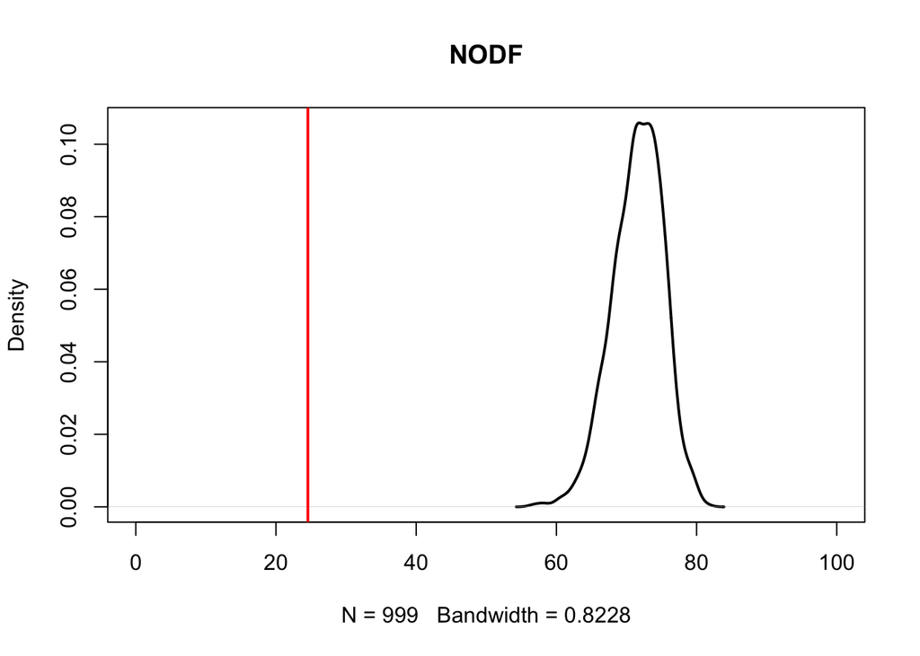

```r
data(Safariland)
Iobs <- networklevel(Safariland, index = "NODF")[[1]]
nulls <- nullmodel(web=Safariland, N = 999, method = 'r2dtable') # can take a while...
Inulls <- sapply(nulls, function(x) nestednodf(x)$statistic[3])
plot(density(Inulls), xlim = c(0, 100), lwd = 2, main = "NODF")
# plot(hist(Inulls), xlim=c(0, 100), lwd=2, main="NODF") # histogram
abline(v=Iobs, col="red", lwd=2)
```

Calculate the (two-tailed) $p$-value for the above null model analysis, using the code below:

```r
# two-tailed p-value for permutation test with null models
pval = (min(length(which(Inulls>Iobs)), length(which(Iobs>Inulls))+1) /
          length(c(Iobs,Inulls)))*2
pval
```

```
## [1] 0.002
```

as indicated in the exercise, your $p$-value should be exactly 0.002.

**how do you interpret your result?** think about whether your result is statistically significant as well as the *directionality* of the result:

- here the **directionality** of the result is that the value of NODF is *lower* in the empirical data (red line) than in the null model simulations—in other words, the Safariland network is *LESS nested* than expected by chance, as assessed with the `r2dtable` null model
- since the $p$-value is less than 0.05, we can say that this result is statistically significant

### Optional bonus 10.1

Re-run the analysis above with the `swap.web` null model (this is a very straightforward replacement of `r2dtable` with `swap.web`) above.

here is the code and graph for that:

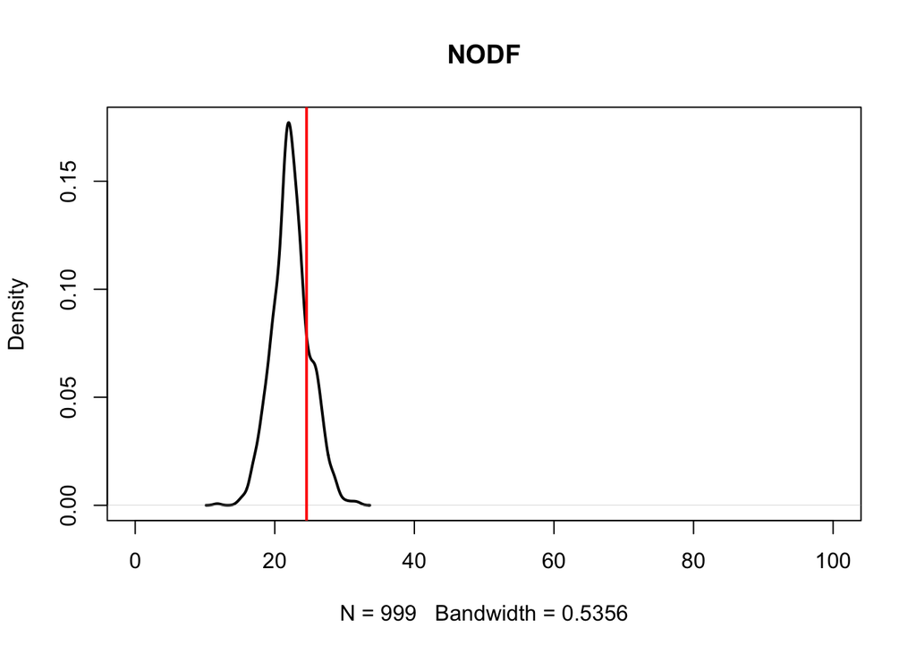

```r
data(Safariland)
Iobs <- networklevel(Safariland, index = "NODF")[[1]]
nulls <- nullmodel(web=Safariland, N = 999, method = 'swap.web') # can take a while...
Inulls <- sapply(nulls, function(x) nestednodf(x)$statistic[3])
plot(density(Inulls), xlim = c(0, 100), lwd = 2, main = "NODF")
# plot(hist(Inulls), xlim=c(0, 100), lwd=2, main="NODF") # histogram
abline(v=Iobs, col="red", lwd=2)
```

You should get a qualitatively different result relative to using `swap.web`. Describe where the empirical value falls out relative to the null models.

- this is the same as the graph Berry showed in the workshop presentation; the empirical value falls out in the middle of the null distribution
- this is strikingly different than the result using `r2dtable`, where the empirical value was *much* smaller than the null models

**Calculate the $p$-value if you have time**

here is the code for that:

```r
# two-tailed p-value for permutation test with null models
pval = (min(length(which(Inulls>Iobs)), length(which(Iobs>Inulls))+1) /
          length(c(Iobs,Inulls)))*2
pval
```

```
## [1] 0.392
```

Because of the element of randomness in generating null networks, if you repeat this procedure multiple times or on multiple computers, you can get slight variations in the exact value, but it should be pretty close to ~0.392.

### Optional bonus 10.2

Using our discussion of the correlation among network metrics, as well as our descriptions of the null models, offer an interpretation as to *why* the two null models (`r2dtable` and `swap.web`) yield qualitatively different results.

- `r2dtable` does not hold the number of links or connectance constant. Since there are many possible interactions that could be randomly assigned, this null model tends to generate a much higher connectance than raw data
  - In this case, the connectance of the null networks is *much* higher—about twice as high—as in the empirical network
  - one way to see that graphically would be to call `visweb(as.matrix(nulls[[1]]))`—doing that after having run the nulls with `swap.web`, you’ll see that the connectance is identical to the “Safariland” network (`visweb(Safariland)`); if you re-run with `r2dtable`, you’ll be able to see the much greater connectance
- as Fernanda discussed in the workshop component of correlations among network metrics, higher connectance alone inevitably increases nestedness; this is almost certainly the driver of the difference between null models in this case

### Optional bonus 10.3

Try one of the null models implemented in `vegan`, in particular `quasiswap_count`. Code was included for the null models in the exercise, but that code chunk didn’t include the last two lines for plotting. Here is the code (with the plotting included), and the plot below:

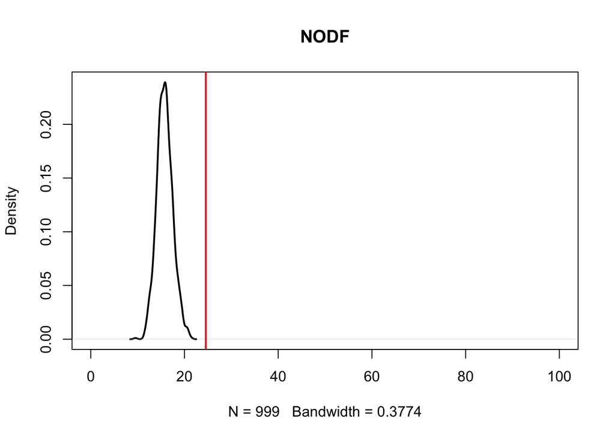

```r
# alternative: use vegan::nullmodel rather than bipartite
library(vegan)
# require first setting up a null model, then separately simulating it
n.vegan <- vegan::nullmodel(Safariland, "quasiswap_count") #setup
nulls.vegan <- simulate(n.vegan, nsim = 999) #simulation
# the vegan `simulate` method returns a 3-dimensional numeric array
# so need to modify the code used for the bipartite nulls
# use `apply` rather than `sapply` with MARGIN = 3
Inulls.vegan <- apply(nulls.vegan, MARGIN = 3,
                      FUN = function(x) nestednodf(x)$statistic[3])

# plot it
plot(density(Inulls.vegan), xlim = c(0, 100), lwd = 2, main = "NODF")
abline(v=Iobs, col="red", lwd=2)
```

The exercise said: *You should get again a qualitatively different result relative to `swap.web`. This is somewhat curious as the two methods are supposed to be very similar… (we are not sure why!)*

- we can see straightaway that using `quasiswap_count` that our empirical data appear to be significantly *more* nested than by chance alone, as opposed to falling out in the middle of the distribution with `swap.web`
- again, because these two approaches are supposed to be similar in terms of holding connectance and degree distribution constant, it is surprising that they generate different results, and we are not sure why this is the case!